# Session 5 - Visualisierung & Recap

22. Mai 2018

## Syllabus

Session 1 - R and RStudio

Session 2 - Data Typen und erste Befehle

Session 3 - Daten einlesen und speichern

Session 4 - Einfache Analyse (numerisch)

`Session 5 - Visualisierung`

Session 6 - Application Programming Interfaces (APIs)

Session 7 - Introduction to Text Mining

Session 8 & 9 - Web Scraping

## Agenda

1. Hausaufgaben besprechen
2. Kontrollstrukturen
3. For-Loop
4. Aufgaben
5. Visualisierung
6. Hausaufgaben

## 1. Hausaufgaben besprechen

## Aufgaben (1)

- Was ist der Median von `nkill`?

```r
median(gtdb$nkill, na.rm = TRUE)
```

```
## [1] 1
```

- Wieviele Selbstmordanschläge gab es?

```r
sum(gtdb$suicide == 1)
```

```
## [1] 5672
```

## Aufgaben (2)

- Wieviele verschiedene Kategorien hat die Variable `attacktype1_txt`?

```r
table(gtdb$attacktype1_txt)
```

```
##
##                                   1                                   2
##                                   2                                   2
##                                   7                       Armed Assault
##                                   1                               24600
##                       Assassination                   Bombing/Explosion
##                                6191                               54877
##      Facility/Infrastructure Attack                           Hijacking
##                                5065                                 262
## Hostage Taking (Barricade Incident)         Hostage Taking (Kidnapping)
##                                 280                                7262
##                     Unarmed Assault                             Unknown
##                                 558                                3815
```

## Aufgaben (3)

- Wieviele Selbstmordanschläge gab es im Jahr 2003?

```r
sum(gtdb$iyear == 2003 & gtdb$suicide == 1)
```

```
## [1] 86
```

- Wie oft wurde das russische Militär angegriffen?

```r
sum(gtdb$natlty1 == 167 & gtdb$targtype1 == 4, na.rm = TRUE)
```

```
## [1] 207
```

```r
sum(gtdb$natlty1_txt == "Russia" & gtdb$targtype1_txt == "Military", na.rm = TRUE)
```

```
## [1] 207
```

## Aufgaben (4)

- Wie oft war ein Selbstmordanschlag mit einer Bombe erfolgreich?

```r
sum(gtdb$suicide == 1 &
      gtdb$attacktype1  == 3 &
      gtdb$success == 1, na.rm = TRUE)
```

```
## [1] 4651
```

- Bestimme alle Kennzahlen von `nkill` und interpretiere diese.

```r
summary(gtdb$nkill)
```

```
##     Min.  1st Qu.   Median     Mean  3rd Qu.     Max.     NA's
##    0.000    0.000    1.000    2.531    2.000 1500.000     3653
```

## Aufgaben (5)

- Wie hoch ist der `mean` bei Selbstmordanschläge? Wie hoch bei allen anderen Fällen?

```r
mean(gtdb$nkill[gtdb$suicide == 1], na.rm = TRUE)
```

```
## [1] 10.36965
```

```r
mean(gtdb$nkill[gtdb$suicide != 1], na.rm = TRUE)
```

```
## [1] 2.064485
```

## Aufgaben (6)

- Wieviel Anschläge gab es im Jahr 2009 bei dem das Ziel eine `Educational Institution` oder das angegriffene Ziel aus `East Timor` war?

```r
nrow(gtdb[gtdb$iyear == 2009 &
            (gtdb$targtype1_txt == "Educational Institution" |
               gtdb$natlty1_txt == "East Timor"), ])
```

```
## [1] 239
```

- Wie oft könnte die Opferzahl nicht ermittelt werden?

```r
sum(is.na(gtdb$nkill))
```

```
## [1] 3653
```

## 2. Kontrollstrukturen

## 2. If - Else (1)

```r
age <- 18
if (age >= 18) {
  print("Champagner")
} else {
  print("Limo")
}
```

```
## [1] "Champagner"
```

```r
age <- 14
if (age >= 18) {
  print("Champagner")
} else {
  print("Limo")
}
```

```
## [1] "Limo"
```

## 2. If - Else (2)

- arbeitet auf einem einzelnen Element
- Grundsätzliche Syntax:

```r
if (logische Aussage) {
  statement1
} else {
  statement2
}
```

## 2. Ifelse (3)

- Vektorisierte Variante

```r
ages <- c(11, 19, 25, 14, 30, 99, 12)
ifelse(ages >= 18, "Champagner", "Limo")
```

```
## [1] "Limo"       "Champagner" "Champagner" "Limo"       "Champagner"
## [6] "Champagner" "Limo"
```

- Grundsätzliche Syntax:

```r
ifelse(logische Aussage, statement1, statement2)
```

## 3. Schleifen

## 3. For-Loop (1)

```r
for (index in 1:10) {
  print(index)
}
```

```
## [1] 1
## [1] 2
## [1] 3
## [1] 4
## [1] 5
## [1] 6
## [1] 7
## [1] 8
## [1] 9
## [1] 10
```

## 3. For-Loop (2)

- Wiederholte Ausführung eines Befehls
- Grundsätzliche Syntax:

```r
for (index in vector){
  statements
}
```

## 3. For-Loop mit If- Statement (3)

```r
suicide_counter <- 0

for (index in 1:nrow(gtdb)) {
  if (gtdb$suicide[index] == 1) {
    suicide_counter <-  suicide_counter + 1
  } else {
    suicide_counter <- suicide_counter + 0
  }
}

suicide_counter
```

```
## [1] 5672
```

## 4. Aufgaben

1. Schreibe eine For-Loop, in der die Quadratzahlen von 1 bis 10 ausgegeben werden
2. Erstelle einen Vektor *half_of_year*, der eine 0 angibt, wenn der Anschlag im ersten Halbjahr des Jahres stattgefunden hat, und eine 1 für die zweite Jahreshälfte.
3. Bestimme mit Hilfe einer For-Loop die Anzahl aller getöteten Personen für den gesamten Datensatz. Welche andere Funktion erledigt das mit einer Zeile Code?

## 5. Visualisierung

## Scatterplot (1)

[figure not shown]

## Scatterplot (2)

```r
plot(latitude ~ longitude,
     xlab = "Longitude",
     ylab = "Latitude",
     main = "Attack ",
     las = 0.2,
     pch = 20,
     data = gtdb)
```

## Histogramm (1)

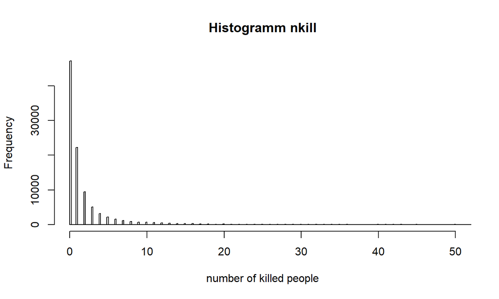

## Histogramm (2)

```r
hist(gtdb$nkill,
     breaks = 10000,
     xlim = c(0,50),
     main = "Histogramm nkill",
     xlab = "number of killed people")
```

## Barplots (1)

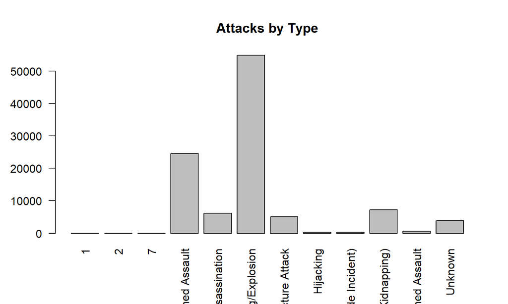

## Barplots (2)

```r
attacks <- table(gtdb$attacktype1_txt)
barplot(attacks,
        main="Attacks by Type",
        las=2)
```

## Boxplots (1)

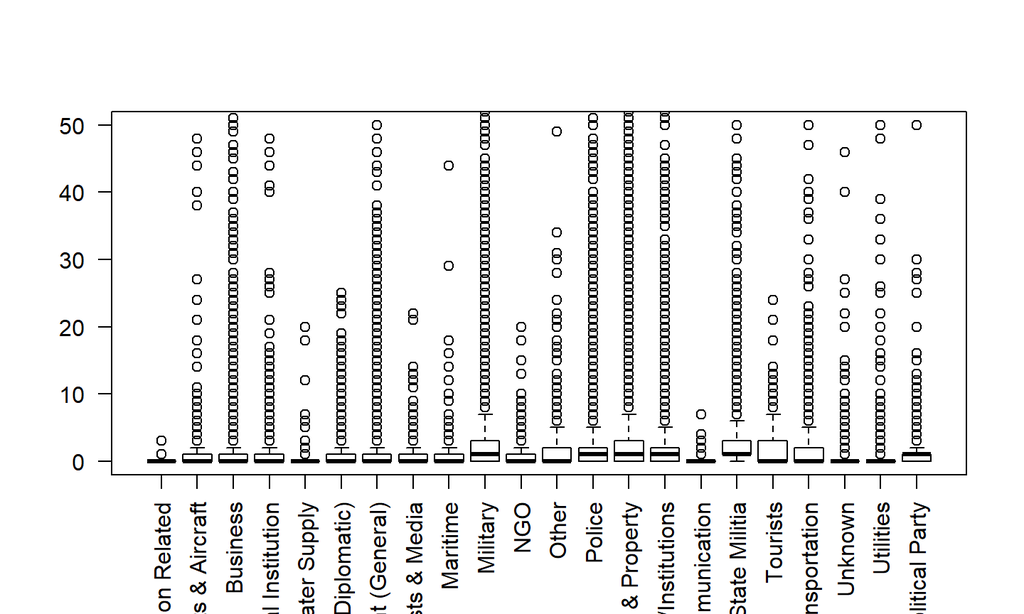

## Boxplots (2)

```r
boxplot(nkill ~ targtype1_txt,
        na.action = "na.omit",
        data = gtdb,
        las = 2,
        ylim = c(0, 50))
```

## 6. Hausaufgaben

1. In dem Datensatz hat sich bei *attacktype1_txt* bei manchen Variablen ein Fehler eingeschlichen. Ändere die numerischen Werte in ihre String-Repräsentation. Erstelle nun einen neuen Barplot, bei dem auch die Variablenname passen. Änder dazu entweder die **Schriftgröße** oder passe die Variablennamen an. *Für Fortgeschrittene:* Schau dir `par()` an, um die Plottingcanvas anzupassen.

### Tipp:

Für zusätzliche Features in eurem Plot (Finetuning) findet ihr eine Anzahl an Funktionen hier: https://de.wikibooks.org/wiki/GNU_R:_plot